# Reanalysis Grant Bioinformatician Exercise

Min Wang

December 10, 2022

## Background

The exercise was originally posted [here](https://docs.google.com/document/d/1sw98QNgSVr0WjTzDB8sHa1H-pULjU31qvLO39dfTcVw).

The dataset for testing was cloned from [here](https://gitlab.com/ssadedin/cnv_data_exercise).

## Set Up

```r
# Get R libraries
list.of.packages <- c('data.table', 'purrr', 'ggplot2', 'ggfortify',
                      'factoextra', 'FactoMineR', 'corrplot', 'ggpubr', 'outliers')
new.packages <- list.of.packages[!(list.of.packages %in% installed.packages()[,"Package"])]
if(length(new.packages)) install.packages(new.packages)
lapply(list.of.packages, require, character.only = TRUE)

# Get Bioconductor libraries
if (!require("BiocManager", quietly = TRUE)) install.packages("BiocManager")
list.of.packages <- c('Rsamtools', 'GenomicFeatures', 'GenomicAlignments', 'BiocParallel')
new.packages <- list.of.packages[!(list.of.packages %in% installed.packages()[,"Package"])]
if(length(new.packages)) BiocManager::install(new.packages)
lapply(list.of.packages, require, character.only = TRUE)

options(scipen = 999) # force not to use scienteific notation
set.seed(1234)
```

The list of bam files have been loaded as the `bamfiles` object.

```r
filenames <- list.files(path = inpath1, pattern = 'bam$',
                        all.files = TRUE, full.names = TRUE, recursive = TRUE)
bamfiles <- BamFileList(filenames, yieldSize=2000000)
bamfiles
```

```
## BamFileList of length 14
## names(14): XI001.bam XI002.bam XI003.bam ... XI012.bam XI013.bam XI014.bam
```

The target regions have been loaded as the `gr` object.

```r
data <- fread(infile1, header = FALSE)
setnames(data, c('chr', 'start', 'end', 'width'))
gr <- sort(as(data, 'GRanges'))
gr
```

```
## GRanges object with 79 ranges and 0 metadata columns:
##        seqnames            ranges strand
##           <Rle>         <IRanges>  <Rle>
##    [1]     chrX 31119228-31121932      *
##    [2]     chrX 31126642-31126675      *
##    [3]     chrX 31134102-31134196      *
##    [4]     chrX 31146291-31146416      *
##    [5]     chrX 31147275-31147520      *
##    ...      ...               ...    ...
##   [75]     chrX 32823295-32823389      *
##   [76]     chrX 32844783-32844862      *
##   [77]     chrX 32849728-32849822      *
##   [78]     chrX 33020139-33020202      *
##   [79]     chrX 33211282-33211558      *
##   -------
##   seqinfo: 1 sequence from an unspecified genome; no seqlengths
```

```r
n <- length(gr)
x <- end(gr)[1:n-1]
y <- start(gr)[2:n]
z <- abs(x-y)
```

The vector below shows that most target regions are far away from each other, with gaps larger than the expected read length (i.e. 150bp), although there are two target regions close to each other, with a gap of 106bp in between.

```r
sort(z)
```

```
##  [1]    106    308    395    607    649    697    850    859    990   1112
## [11]   1124   1563   1622   2255   2324   2333   2462   2655   2745   2788
## [21]   2829   3034   3452   3797   4326   4710   4866   5628   6022   6176
## [31]   6653   6855   7140   7427   7647   8605  10235  10335  12095  12608
## [41]  13346  14258  15309  16164  16633  17683  18425  20366  21055  21229
## [51]  21394  21569  21909  21923  22379  24896  26326  27026  29677  30126
## [61]  31822  33477  36110  37832  38367  44210  45781  50043  52716  54221
## [71]  62580  70464  95845 110198 120218 170317 191080 248400
```

Our read counting method below will work for most target regions except this one.

## Get Read Counts

1. We would like to know the count of reads that overlap each target region for each sample. Use a command line tool or notebook / script to create a file containing a matrix of the read counts where the columns are the target regions and the rows are the read counts.

Your answer should look approximately like the file provided in example_results/counts.tsv (exact answers may vary due to subtle issues of how read overlaps or boundaries are considered - do not worry about this).

```r
# mode = "Union" : (Default) Reads that overlap any portion of exactly one feature are counted.
#                  Reads that overlap multiple features are discarded.
#                  This is the most conservative of the 3 modes.
# fragments = FALSE: (Default FALSE) A logical; applied to paired-end data only.
#                    ‘fragments’ controls which function is used to read the data which subsequently
#                    affects which records are included in counting.
#                    When ‘fragments=FALSE’, data are read with ‘readGAlignmentPairs’ and returned
#                    in a ‘GAlignmentPairs’ class.
#                    In this case, singletons, reads with unmapped pairs, and other fragments, are dropped.
se <- summarizeOverlaps(features = gr, reads = bamfiles,
                        mode = "Union", singleEnd = FALSE,
                        ignore.strand = TRUE, fragments = FALSE)
tmp1 <- t(assay(se))
colnames(tmp1) <- paste(as.character(seqnames(gr)), paste(start(gr), end(gr), sep = '-'), sep = ':')
tmp2 <-  as.matrix(x = gsub('.bam', '', rownames(tmp1)), ncol = 1)
colnames(tmp2) <- 'sample'
data <- cbind(as.data.table(tmp2), as.data.table(tmp1))
data[1:2, 1:4]
```

```
##    sample chrX:31119228-31121932 chrX:31126642-31126675 chrX:31134102-31134196
## 1:  XI001                     34                     20                     37
## 2:  XI002                     48                     39                     44
```

```r
write.table(x = data, file = 'results/counts.tsv', append = FALSE,
            quote = FALSE, sep = '\t', row.names = FALSE, col.names = TRUE)
```

2. Use your preferred data analysis language to normalise each sample by dividing out its mean coverage - save this file as results/mean.counts.tsv

```r
dat <- data[, grep('chr', names(data), value = TRUE), with = FALSE]
res <- data.table(sample = data$sample, mean_coverage = rowMeans(dat))
res[1:2,]
```

```
##    sample mean_coverage
## 1:  XI001      29.35443
## 2:  XI002      41.44304
```

```r
write.table(x = res, file = 'results/mean.counts.tsv', append = FALSE,
            quote = FALSE, sep = '\t', row.names = FALSE, col.names = TRUE)
```

## Get PCA

3. Create a PCA plot of the mean counts showing the first two principle components (paste a picture of it here), and show the code or commands you used to create it.

```r
dat[1:2, 1:3]
```

```
##    chrX:31119228-31121932 chrX:31126642-31126675 chrX:31134102-31134196
## 1:                     34                     20                     37
## 2:                     48                     39                     44
```

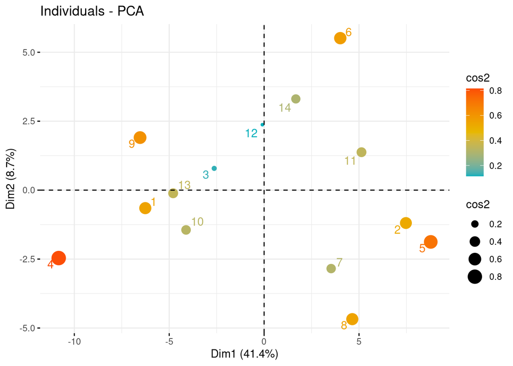

```r
res.pca <- PCA(dat, graph = FALSE)
fviz_pca_ind(res.pca,
             col.ind = "cos2", pointsize = "cos2",
             gradient.cols = c("#00AFBB", "#E7B800", "#FC4E07"),
             repel = TRUE # Avoid text overlapping (slow if many points)
             )
```

## Intepret PCA

4. Describe what you see in the PCA plot. Can you interpret anything from the data?

The PCA plot above shows that:

- The first principal component (PC1) explains 41.4% variation of read counts in the dataset (x-axis).
- The second principal component (PC2) explains 8.7% variation of read counts in the dataset (y-axis).
- Individual 4 has a read count profile most different from other individuals, shown as the largest dot size in red colour furtherest away from the centre of the coordinates.
- Individual 5 has a read count profile second the most different from other individuals, shown as the second largest dot size in orange colour also further away from the centre of the coordinates.

The eigenvalues for each PC are listed below.

- The first 2 PCs explain 50% of variation of read counts.
- The first 5 PCs explain 70% variation of read counts.

```r
eig.val <- get_eigenvalue(res.pca)
eig.val
```

```
##        eigenvalue variance.percent cumulative.variance.percent
## Dim.1   32.716284        41.413018                    41.41302
## Dim.2    6.900914         8.735335                    50.14835
## Dim.3    5.627062         7.122863                    57.27122
## Dim.4    5.215298         6.601644                    63.87286
## Dim.5    4.965015         6.284829                    70.15769
## Dim.6    4.784476         6.056299                    76.21399
## Dim.7    4.311703         5.457852                    81.67184
## Dim.8    3.767454         4.768929                    86.44077
## Dim.9    2.758337         3.491566                    89.93233
## Dim.10   2.482461         3.142355                    93.07469
## Dim.11   2.327897         2.946705                    96.02139
## Dim.12   1.890408         2.392921                    98.41432
## Dim.13   1.252691         1.585685                   100.00000
```

## Special Samples

5. Based on your findings, are there any particular samples you would recommend to treat specially or differently in this data?

To identify whether or not there are outliers in the dataset, the target region with the most varied read counts was selected.  
An Grubbs’s test was performed to detect whether or not there are outliers in the most varied target region.  
No outlier was identified, indicating that no sample or target region needs to be removed due to potential technical errors.

```r
plvl <- 0.01
res.desc <- dimdesc(res.pca, axes = 1, proba = plvl)
cns <- rownames(res.desc$Dim.1[[1]])[1]
x <- array(dat[, cns, with = F])[[1]]
grubbs.test(x)
```

```
##
##  Grubbs test for one outlier
##
## data:  x
## G = 1.77731, U = 0.73832, p-value = 0.4306
## alternative hypothesis: lowest value 25 is an outlier
```

6. If you identified any samples, can you interpret anything about them?

To identify candidate heterozygous deletion or duplication of target regions:  
Firstly, the answer to question 2, mean coverage by sample (data table below), has shown that across all target regions, individual 4 and 5 have the lowest and highest mean read coverage among all individuals, respectively.  
The PCA plot agrees with the answer to question 2.

```r
res
```

```
##     sample mean_coverage
##  1:  XI001      29.35443
##  2:  XI002      41.44304
##  3:  XI003      32.37975
##  4:  XI004      25.68354
##  5:  XI005      42.29114
##  6:  XI006      38.65823
##  7:  XI007      37.87342
##  8:  XI008      38.92405
##  9:  XI009      29.36709
## 10:  XI010      31.58228
## 11:  XI011      39.22785
## 12:  XI012      35.17722
## 13:  XI013      30.45570
## 14:  XI014      36.36709
```

The contribution plot below shows that read counts in target region `chrX:31679375-31679588` and `chrX:32472164-32472311` vary the most among all individuals.

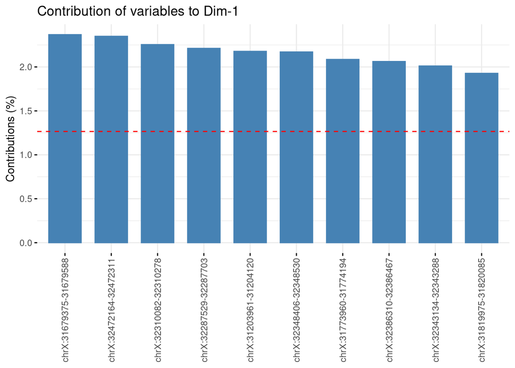

```r
fviz_contrib(res.pca, choice = "var", axes = 1, top = 10, xtickslab.rt = 90)
```

```r
x <- dat$"chrX:31679375-31679588"
dt <- x / mean(x)
dt
```

```
##  [1] 0.5709625 1.3474715 1.1419250 0.7536705 1.3474715 1.0734095 1.0277325
##  [8] 1.1876020 0.7765090 0.7079935 1.2104405 0.9135400 0.8678630 1.0734095
```

The Q-Q plot below shows that individuals’ read counts in this target region are fairly normally distributed, as most dots falling on the diagonal straight line.

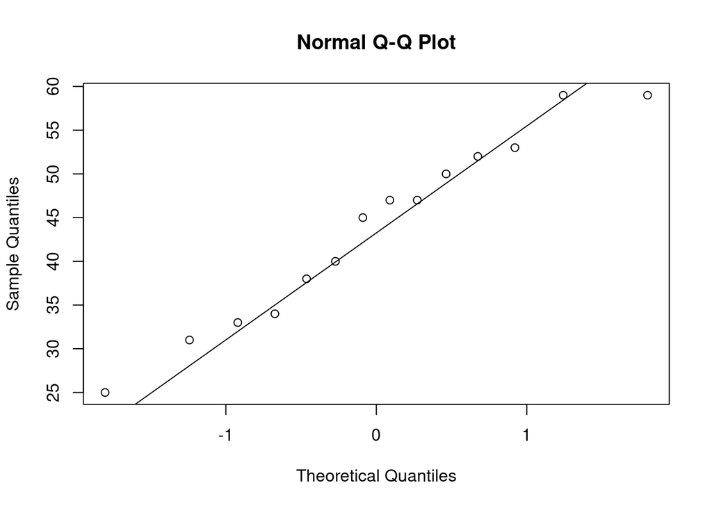

```r
qqnorm(x)
qqline(x)
```

A one-sample t-test was performed to compare read counts of individual 2 and 5 with that of other individuals.  
The test examines whether or not the mean read counts of other individuals fewer than the read count of individual 2 and 5 is statistically significant, but the test does not examine whether or not the difference in read counts is sufficient to suggest a heterozyous duplication in individual 2 and 5.  
Results show that individual 2 and 5 have read counts statistically significantly larger than other individuals in the target region.  
There are 79 target regions.  
Multiple testings occur when a one-sample t-test is performed for each target region.  
Given a p-value threshold of 0.01, after Bonferroni correction, the test p-value remains significant, indicating that individual 2 and 5 may have a copy number duplication in the target region `chrX:31679375-31679588`.  
This target region falls within an exon of the Duchenne muscular dystrophy (DMD) gene, where copy number duplication is a known mechanism of diseases ([Decipher](https://www.deciphergenomics.org/gene/DMD/browser) and [GnomAD](https://gnomad.broadinstitute.org/gene/ENSG00000198947?dataset=gnomad_sv_r2_1)).  
Whether this candidate copy number duplication is relevant to disease or not will depend on the clinical presentations of individaul 2 and 5.

```r
ttest <- t.test(x = x[c(1, 3:4, 6:14)], mu = x[5], alternative = 'less')
ttest
```

```
##
##  One Sample t-test
##
## data:  x[c(1, 3:4, 6:14)]
## t = -6.7519, df = 11, p-value = 0.00001575
## alternative hypothesis: true mean is less than 59
## 95 percent confidence interval:
##      -Inf 45.97116
## sample estimates:
## mean of x
##     41.25
```

```r
ttest$p.value < 0.01/ncol(dat)
```

```
## [1] TRUE
```

The vector below shows that:

- Individual 4 has the smallest read counts in target region `chrX:32472164-32472311` among all individuals.
- Read counts of individual 4 is 0.65 times fewer than the mean read count of other individuals.
- Individual 5 has the largest read counts in target region `chrX:32472164-32472311` among all individuals.
- Read counts of individual 5 is 1.45 times more than the mean read count of other individuals.

```r
x <- dat$"chrX:32472164-32472311"
dt <- x / mean(x)
dt
```

```
##  [1] 0.6701164 1.0323415 1.0504528 0.6520052 1.4489004 1.2677878 1.0685640
##  [8] 1.1591203 0.7968952 0.7425614 1.2315653 0.8512290 0.9055627 1.1228978
```

The Q-Q plot below shows that individuals’ read counts in this target region are fairly normally distributed, as most dots falling on the diagonal straight line.

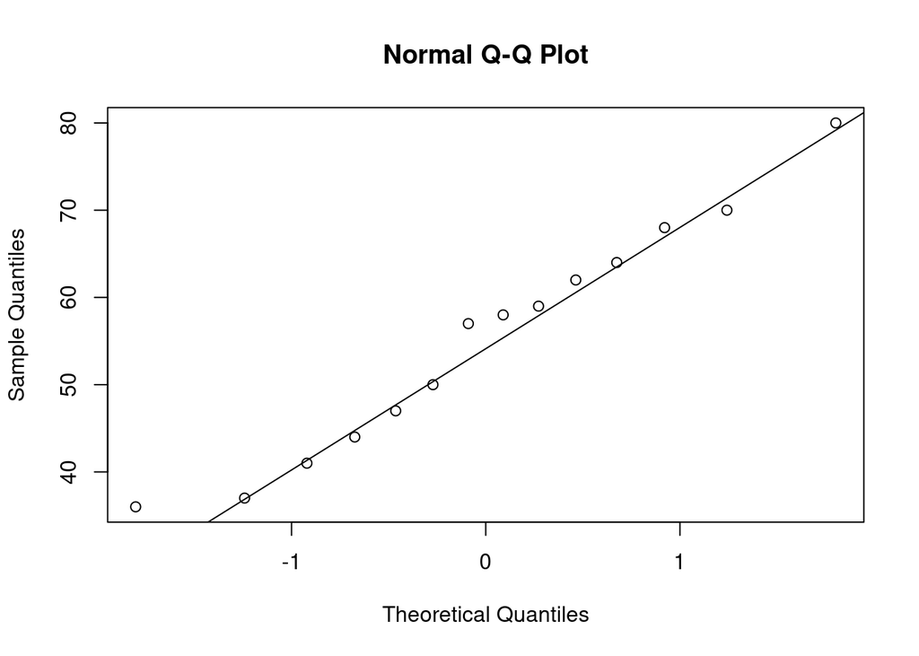

```r
qqnorm(x)
qqline(x)
```

A one-sample t-test was performed to compare read counts of individual 4 with that of other individuals.  
The test examines whether or not the mean read counts of other individuals larger than the read count of individual 4 is statistically significant, but the test does not examine whether or not the difference in read counts is sufficient to suggest a heterozyous deletion in individual 4.  
Results show that individual 4 has read counts statistically significantly fewer than other individuals in the target region.  
There are 79 target regions.  
Multiple testings occur when a one-sample t-test is performed for each target region.  
Given a p-value threshold of 0.01, after Bonferroni correction, the test p-value remains significant, indicating that there could be a copy number deletion in the target region.  
This target region falls within an exon of the Duchenne muscular dystrophy (DMD) gene, where copy number deletion is a known mechanism of diseases ([Decipher](https://www.deciphergenomics.org/gene/DMD/browser) and [GnomAD](https://gnomad.broadinstitute.org/gene/ENSG00000198947?dataset=gnomad_sv_r2_1)).  
Whether or not this candidate copy number deletion is relevant to disease will depend on the clinical presentation of individaul 4.

```r
ttest <- t.test(x = x[c(1:3, 5:14)], mu = x[4], alternative = 'greater')
ttest
```

```
##
##  One Sample t-test
##
## data:  x[c(1:3, 5:14)]
## t = 5.9753, df = 12, p-value = 0.00003228
## alternative hypothesis: true mean is greater than 36
## 95 percent confidence interval:
##  50.52031      Inf
## sample estimates:
## mean of x
##  56.69231
```

```r
ttest$p.value < 0.01/ncol(dat)
```

```
## [1] TRUE
```

A one-sample t-test was performed to compare read counts of individual 5 with that of other individuals.  
The test examines whether or not the mean read counts of other individuals fewer than the read count of individual 5 is statistically significant, but the test does not examine whether or not the difference in read counts is sufficient to suggest a heterozyous duplication in individual 5.  
Results show that individual 5 has read counts statistically significantly larger than rest of the individuals in the target region.  
There are 79 target regions.  
Given a p-value threshold of 0.01, after Bonferroni correction, the test p-value remains significant, indicating that there could be a copy number duplication in the target region.  
The target region falls within an exon of the Duchenne muscular dystrophy (DMD) gene, where copy number duplication is a known mechanism of diseases ([Decipher](https://www.deciphergenomics.org/gene/DMD/browser) and [GnomAD](https://gnomad.broadinstitute.org/gene/ENSG00000198947?dataset=gnomad_sv_r2_1)).  
Whether or not this candidate copy number duplication is relevant to disease will depend on the clinical presentation of individaul 5.

```r
ttest <- t.test(x = x[c(1:4, 6:14)], mu = x[5], alternative = 'less')
ttest
```

```
##
##  One Sample t-test
##
## data:  x[c(1:4, 6:14)]
## t = -8.3171, df = 12, p-value = 0.00000126
## alternative hypothesis: true mean is less than 80
## 95 percent confidence interval:
##      -Inf 59.02764
## sample estimates:
## mean of x
##  53.30769
```

```r
ttest$p.value < 0.01/ncol(dat)
```

```
## [1] TRUE
```